# Practical 7: Comparing Means

Analysing Data

This practical will help you practice preparing for, conducting, and reporting analyses that compare means between two groups in R. Before you start this practical, you should make sure you review the relevant lecture, as this practical assumes you already know what these analyses are and how to interpret the output. You should also use this practical in combination with the tutorial on the same topic.

## Setting Up

For this practical, you will need this worksheet, RStudio, and a new Markdown document. Remember that you can easily switch between windows with the `Alt` + `↹ Tab` (Windows) and `⌘ Command` + `⇥ Tab` (Mac OS) shortcuts.

### Task 1

Open your analysing_data `R` project in RStudio and open a new Markdown file. Since we will be practicing reporting using inline code, we will need Markdown later on. For the tasks, get into the habit of creating new code chunks as you go.

### Task 2

Aside from loading `tidyverse`, we will also be using `cowplot` and `kableExtra`. If you don’t have any of these packages installed, do that now. **Remember that installing packages is a one-off thing** so don’t put the command that does it in your Markdown. Simply type it into the console and press `↵ Enter`. The `library()` commands should always go in a separate code chunk at the beginning of your Markdown document, so that your code will run correctly.

### Task 3

As usual, we will need some data to work with. Since it’s already cleaned up and we had a look at it, let’s use the harm dataset again that we have seen previously, from [an actual paper by Swiderska and Küster (2018)](https://journals.sagepub.com/doi/10.1177/0301006618809919). You can find the data from the study at https://raw.githubusercontent.com/mivalek/AnD/master/data/harm_data.csv. You will also need to copy and paste in the code that you wrote from Practical 3, and/or that you used in the last practical, to clean this dataset.

**Hint**: Copy and paste in code that saves something or makes a change to the dataset, ie uses the assignment operator `<-`.

## Preparation

As usual, you should remind yourself of what these variables actually mean before you start, using the codebook below.

As a reminder, in the original study the researchers showed each participant one avatar, which could have been one of four possibilities. First, the avatar could have been either a human or robot avatar [variable `Humanness`]. Second, the avatar could have been either harmed or unharmed [variable `Harm`]. So, there were four possible conditions, each representing one of the four possible avatars - namely, `Human_Unharmed`, `Human_Harmed`, `Robot_Unharmed`, and `Robot_Harmed` [variable `Condition`]. The study hypothesised that participants would rate the avatars more highly on `Experience` - that is, whether the avatar had feelings, desires, etc. - if they were harmed, with similar hypotheses for `Agency` and `Consciousness`. They also thought that participants would rate the avatars more highly on experience, agency, and consciousness if they thought the avatars had greater capacity to feel pain [variable `Pain`].

### Task 4

Given the study description above, and with reference to the codebook, write down at least one **operational** hypothesis that we could test with this data. This should define both the predictor and outcome variables, and what the results of the test will show you.

### Codebook

| Variable name | Type | Description |
| --- | --- | --- |
| ID | factor | Unique participant ID |
| Condition | factor | Experimental condition; combination of Humanness and Harm. 1 = Human_Harmed, 2 = Human_Unharmed, 3 = Robot_Harmed, 4 = Robot_Unharmed |
| Humanness | factor | Avatar type: 1 = Human, 2 = Robot |
| Harm | factor | Avatar state: 1 = Harmed, 2 = Unharmed |
| Gender | factor | Participant gender: 1 = Male, 2 = Female |
| Age | continuous | Participant age in years |
| Pain | continuous | Does avatar have capacity to feel pain? 1 = Strongly disagree, 7 = Strongly agree |
| Experience | continuous | Does avatar have experience? 1 = Strongly disagree, 7 = Strongly agree |
| Agency | continuous | Does avatar have agency? 1 = Strongly disagree, 7 = Strongly agree |
| Consciousness | continuous | Does avatar have consciousness? 1 = Strongly disagree, 7 = Strongly agree |
| Empathy | continuous | Level of empathy for avatar: Higher number means more empathy felt |
| Attractiveness | continuous | Attractiveness of avatar: Higher number means more attractive |

For the time being, we will focus on the mean ratings of `Experience` in different `Harm` and `Humanness` conditions. Overall, our goal is to find out whether the type of avatar that the participant saw influenced their rating of that avatar’s mental experiences.

## Graphing

Once again, we should graph our data before we jump into running our analysis. Looking at summaries of numbers is good, but there’s no substitute for a good graph to help you understand your data.

### Task 5

Create a nicely formatted means plot, with error bars, of `Experience`, split up by `Harm`, and save it as `harm.means.plot`.

**Hint**: See the tutorial for how to do this. You are welcome to customise the plot (e.g. colour and shape) however you like.

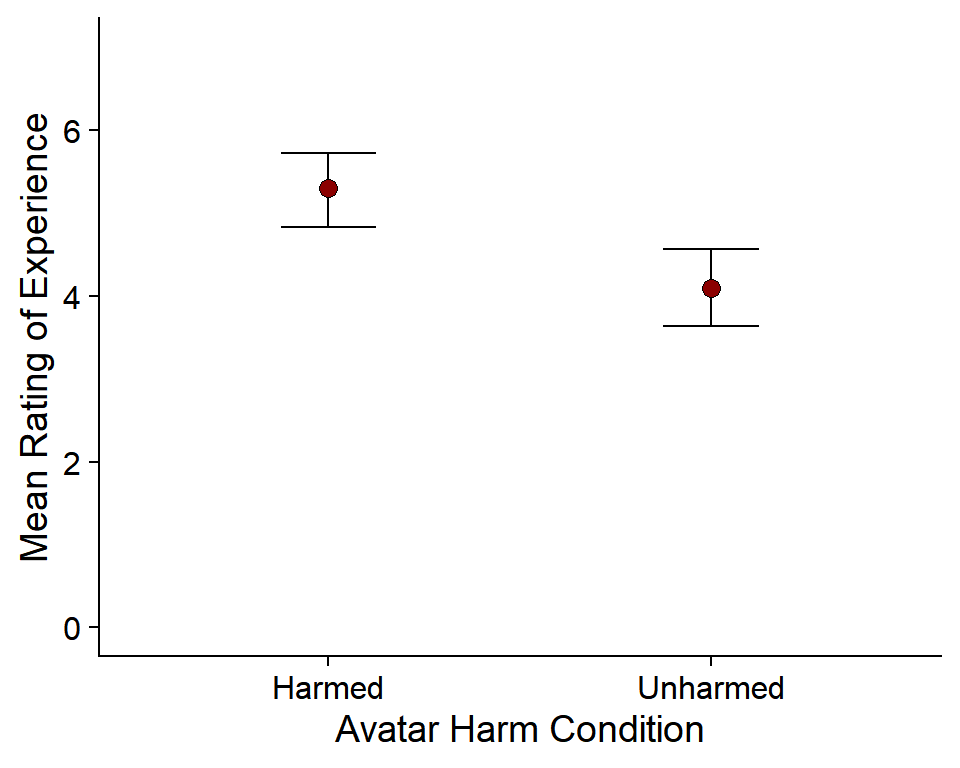

#### Task 5.1

Before you move on, stop and think about what the means plot tells you about our research question.

### Task 6

Create a nicely formatted means plot, with error bars, of `Experience`, split up by `Humanness`, and save it as `human.means.plot`.

**Hint**: See the tutorial for how to do this. You are welcome to customise the plot (e.g. colour and shape) however you like.

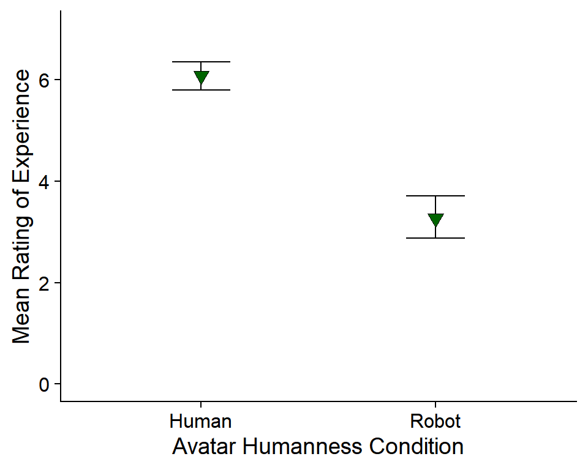

#### Task 6.1

Before you move on, stop and think about what this means plot tells you about our research question.

These two plots give us a clear idea of how participants rated the avatars in the two `Harm` and `Humanness` conditions. However, these conditions were combined in the original study, and there may be a combined effect of both `Harm` and `Humanness` on ratings. Let’s create a plot to visualise this.

### Task 7

Create a nicely formatted means plot, with error bars, of `Experience`, split up by `Harm`, and faceted on `Humanness`. Save it as `int.means.plot`.

**Hint**: Use `facet_wrap(~...)` to get separate plots. You are welcome to customise the plot (e.g. colour and shape) however you like.

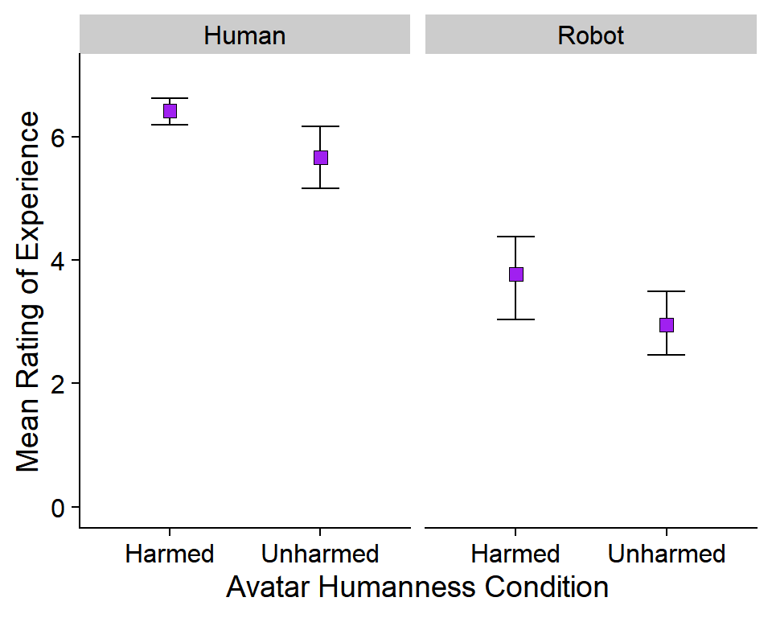

#### Task 7.1

Before you move on, stop and think about what this means plot tells you about our research question.

#### Task 7.2

**CHALLENGE**: Create the same `int.means.plot` as above, but try to fill the points differently for Harmed vs Unharmed avatars. You should also remove the legend.

**Hint**: You will need to add an element to your `aes()` variable mapping, and have a look at `scale_fill_manual()`.

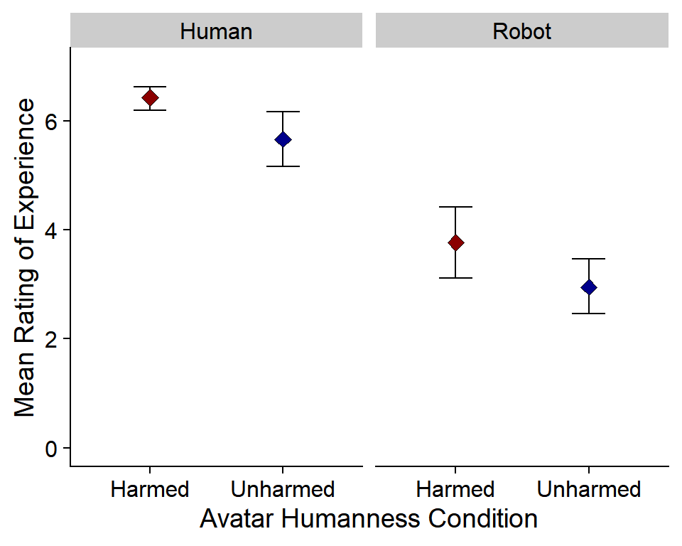

## Using `t.test()`

Now that we have an idea of the pattern of the means, we can choose do some analyses to find out whether these differences are statistically significant.

### Task 8

Using the formula method, run a *t*-test comparing the mean ratings of `Experience` in different `Harm` groups and save it as `harm.t`.

```
    Two Sample t-test

data:  Experience by Harm
t = 3.5194, df = 130, p-value = 0.0005968
alternative hypothesis: true difference in means is not equal to 0
95 percent confidence interval:
 0.5238952 1.8690856
sample estimates:
  mean in group Harmed mean in group Unharmed
              5.295082               4.098592
```

#### Task 8.1

Report the results of this test in APA style, using subsetting and inline code to report values from the output.

#### Task 8.2

Explain in your own words what these results tell you about the relationship between `Harm` and `Experience`.

## Using `lm()`

As we saw in the lecture and tutorial, we can also compare differences in means using a linear model, or LM. Let’s try doing this with the other predictor of interest, `Humanness`.

### Task 9

Create a linear model capturing the relationship between `Humanness` and `Experience`, and save it as `human.lm`.

```
Call:
lm(formula = Experience ~ Humanness, data = .)

Coefficients:
   (Intercept)  HumannessRobot
         6.077          -2.808
```

#### Task 9.1

How can you interpret both of the numbers in this output?

**Hint**: Calculate the mean ratings of Experience in the Human and Robot conditions separately, and the difference between them.

#### Task 9.2

**CHALLENGE**: Run the following code and have a look at the output. Is the relationship between `Humanness` and `Experience` significant?

```r
human.lm %>% summary()

Call:
lm(formula = Experience ~ Humanness, data = .)

Residuals:
    Min      1Q  Median      3Q     Max
-4.0769 -1.0769 -0.0769  0.9231  3.7313

Coefficients:
               Estimate Std. Error t value Pr(>|t|)
(Intercept)      6.0769     0.1820   33.40   <2e-16 ***
HumannessRobot  -2.8083     0.2554  -10.99   <2e-16 ***
---
Signif. codes:
0 '***' 0.001 '**' 0.01 '*' 0.05 '.' 0.1 ' ' 1

Residual standard error: 1.467 on 130 degrees of freedom
Multiple R-squared:  0.4819,    Adjusted R-squared:  0.4779
F-statistic: 120.9 on 1 and 130 DF,  p-value: < 2.2e-16
```

## Summary

At this point, you have practiced interpreting the output of two different methods of comparing means: `t.test()` and `lm()`. If you want more practice with this, you have an entire dataset to play with, and you are welcome to try running these analyses on different combinations of predictors and outcomes of your choosing. At this point, we have practiced everything you need to know for this module, so you can stop here if you like.

**Optionally**, if you are keen to know the answer to our original research question - that is, how are mean ratings of `Experience` different in different combination of conditions - we will look at that in the final part of this practical, but that will bring us back around to interactions and face to face with familywise error.

## A Closer Look

### Task 10

Have another look at the interaction plot we made earlier and saved in `int.means.plot`. Based on the error bars, which means do you think will be significantly different from each other?

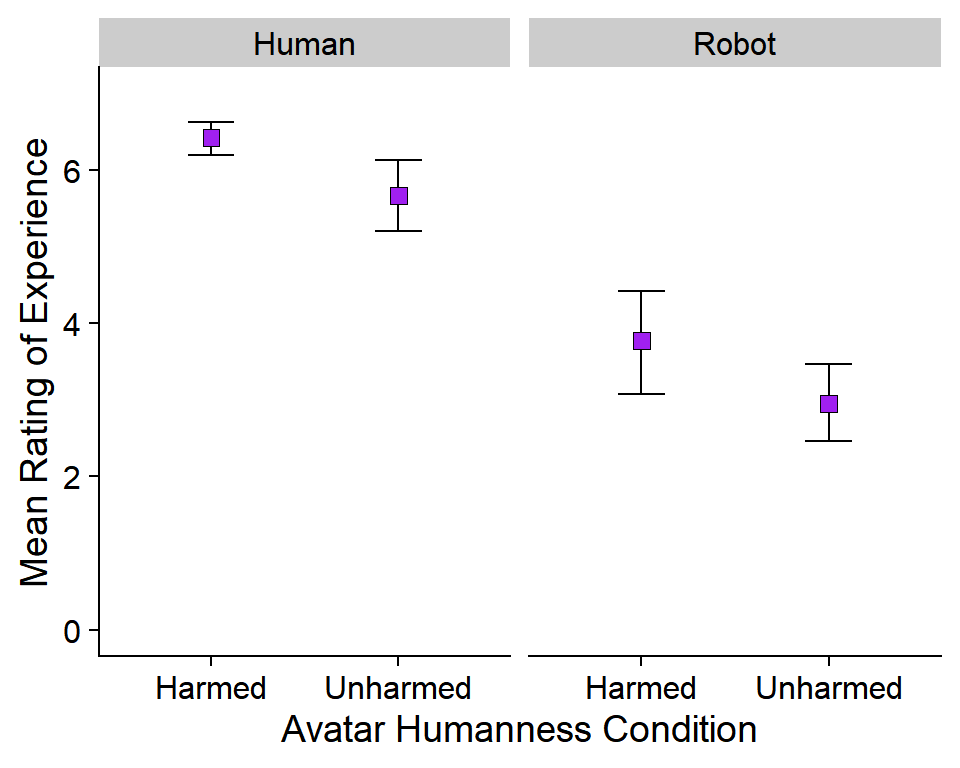

### Task 11

Use a *t*-test to compare the difference in mean ratings of Experience between the `Robot_Harmed` and the `Robot_Unharmed` condition. What can you conclude?

This is a useful thing to know, but we have tested only one pair of conditions, harmed robots vs unharmed robots. Because there are four possible combinations (harmed and unharmed humans and robots), to test all pairs of conditions against each other we would have to do 6 total *t*-tests. Not only does that sound exhausting, it’s extremely inadvisable - in fact, you should **never** do multiple *t*-tests within the same dataset like this. The reason why is briefly explained below.

### Multiple Comparisons

To find out which means in which conditions are different from each other, it seems like the best idea is just compare all combinations of conditions. So, we could start by comparing harmed vs unharmed robots, as we did above. Then, we could compare harmed vs unharmed humans. Then, harmed humans vs harmed robots, then unharmed humans vs unharmed robots, then unharmed humans vs harmed robots, and finally harmed humans vs unharmed robots. We’d have a whole lot of *p*-values to report but then we would know the answer to our original research question…Right?

Not really. Besides the fact that this is repetitive, it doesn’t really capture our research question correctly. Doing the analysis this way treats each pair of means as independent, which they aren’t - because they all come from the same dataset. For example, we could do two *t*-tests comparing harmed vs unharmed robots, and harmed robots vs harmed humans. But in both tests, we would use the same data: the “harmed robots” group is the same in both comparisons. More importantly, though, we’re coming up against a dramatic inflation of our Type 1 error rate.

The essential problem is that by making lots of comparisons like this, we increase the probability that we will find a statistically “significant” result (that is, a *p*-value lower than .05) that doesn’t actually mean anything. This is Type 1 error, or a false positive. The more comparisons we make, the more likely a false positive becomes. The graph below shows the probability of Type 1 error for the number of comparisons we make:

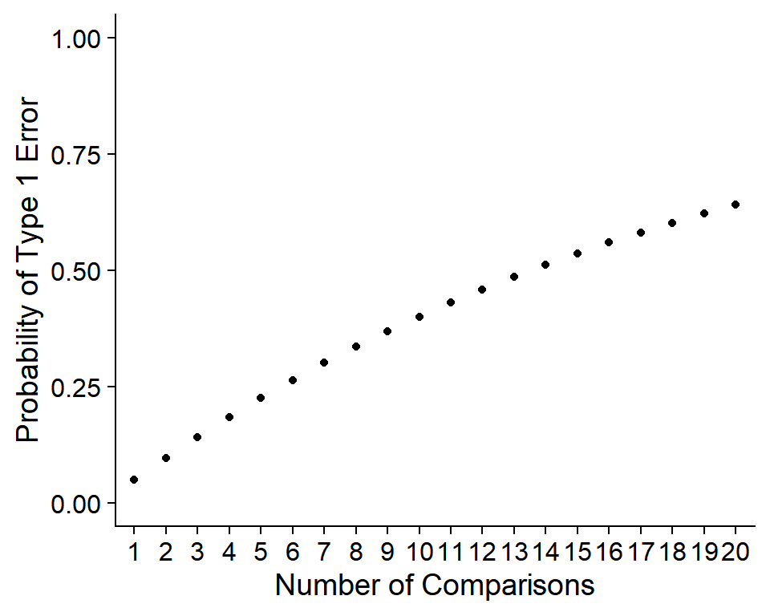

We can see that when we make 6 comparisons, there is about a 25% chance that we will get *at least one* statistically significant result that is actually a false positive.

If you haven’t really understood why this is the case, that’s fine - we will come back to this again in second year and explain in more depth. For now, the main takeaway is that doing multiple uncorrected *t*-tests, like we suggest above, is very bad practice and can lead to completely wrong, misrepresentative conclusions.

## Correcting for Multiple Comparisons

What we would really like is a single model that will capture the effect of `Harm` when we ignore `Humanness`; the effect of `Humanness`, when we ignore `Harm`; **and** the combined effect of `Harm` and `Humanness` together. We cannot do this with *t*-tests, because each *t*-test only compares pairs of means, and we have four means that we want to compare to each other. We can do it easily with the linear model…but we’ll get to that in the future!

For now, instead, we can **adjust our significance level** based on the number of comparisons we make. Essentially, the more familywise (ie related) comparisons we make, the more strict our criteria is for significance. The easiest, and also the most stringent, method of correction is called the Bonferroni correction, and it’s very simple: divide the significance level by the number of comparisons you will make to obtain your new significance level.

### Task 12

Use R to calculate the Bonferroni-adjusted significance level for the comparisons in our dataset and save it as `bonferroni.sig`.

```
[1] 0.008333333
```

This means that we will no longer accept *p* < .05 as significant. To reject the null hypothesis, we require stronger evidence; instead, for each of these six comparisons, *p* must be smaller than .008.

### Task 13

Calculate *t*-tests for each of the six comparisons between conditions for ratings of Experience. Which pairs of means are significantly different from each other, using our corrected significance level?

We will return to the issue of multiple comparisons, and how to construct a better model to capture this complex relationship between predictors, in the future. For now, well done!

## Recap

In sum, today we’ve practiced:

- How to prepare and visualise data for comparing means
- How to conduct a *t*-test, and report and interpret the output
- How to construct a linear model, and report and interpret the output
- How (and why!) to correct for Type 1 error inflation

That’s all for today. See you soon!